# Reproducible Research: Peer Assessment 1

# Analysis of Ativity monitoring data

by Gleb Pishchany  
for

# Reproducible Research Course

## Loading and preprocessing the data

First, I will download the file from here, and unzip it:  
[Activity monitoring data](https://d396qusza40orc.cloudfront.net/repdata%2Fdata%2Factivity.zip)

```r
url<-'https://d396qusza40orc.cloudfront.net/repdata%2Fdata%2Factivity.zip'
download.file(url, dest='activity.zip', method='curl')
unzip('activity.zip')
```

Now let’s load the resulting .csv file into R and take a look at it:

```r
activity<-read.csv('activity.csv')
head(activity)
```

```
##   steps       date interval
## 1    NA 2012-10-01        0
## 2    NA 2012-10-01        5
## 3    NA 2012-10-01       10
## 4    NA 2012-10-01       15
## 5    NA 2012-10-01       20
## 6    NA 2012-10-01       25
```

Right away I want to take a closer look at some of the variables:

```r
str(activity)
```

```
## 'data.frame':    17568 obs. of  3 variables:
##  $ steps   : int  NA NA NA NA NA NA NA NA NA NA ...
##  $ date    : Factor w/ 61 levels "2012-10-01","2012-10-02",..: 1 1 1 1 1 1 1 1 1 1 ...
##  $ interval: int  0 5 10 15 20 25 30 35 40 45 ...
```

I’ll go ahead and change the format of the date variable to make analysis easier later on:

```r
activity$date<-as.Date(as.character(activity$date), '%Y-%m-%d')
summary(activity$date)
```

```
##         Min.      1st Qu.       Median         Mean      3rd Qu.
## "2012-10-01" "2012-10-16" "2012-10-31" "2012-10-31" "2012-11-15"
##         Max.
## "2012-11-30"
```

That looks good, we can see now that we have data acquired between Oct. 1 and Nov.30 (min and max values)

## What is mean total number of steps taken per day?

Note that it you need to first run the part one before running this one.

First, let’s calculate the total number of days recorded each day. I will use dplyr package to 1) Separate the data by date, and 2) calculate the total number of steps for each day

```r
library(dplyr)
activity_by_date<-group_by(activity, date)
daily_steps<-summarize(activity_by_date, steps=sum(steps))
daily_steps
```

```
## Source: local data frame [61 x 2]
##
##          date steps
## 1  2012-10-01    NA
## 2  2012-10-02   126
## 3  2012-10-03 11352
## 4  2012-10-04 12116
## 5  2012-10-05 13294
## 6  2012-10-06 15420
## 7  2012-10-07 11015
## 8  2012-10-08    NA
## 9  2012-10-09 12811
## 10 2012-10-10  9900
## ..        ...   ...
```

Only 126 steps on Oct, 2nd? Must have had a cold and stayed home playing video games.

Next we make a histogram and calculate the stats for steps taken each day:

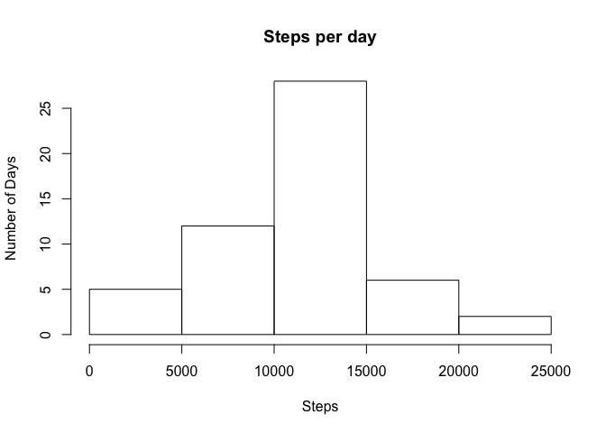

```r
hist(daily_steps$steps, main='Steps per day', ylab='Number of Days', xlab='Steps')
```

```r
summary(daily_steps$steps)
```

```
##    Min. 1st Qu.  Median    Mean 3rd Qu.    Max.    NA's
##      41    8841   10760   10770   13290   21190       8
```